# Лабораторная работа №10

Основы работы с модулями ядра операционной системы

Хохлачева Полина Дмитриевна

Российский университет дружбы народов, Москва, Россия

# Информация

## Докладчик

- Хохлачева Полина Дмитриевна
- Российский университет дружбы народов
- Номер студенческого билета- 1132242473
- [1132242473@pfur.ru]

# Вводная часть

## Цель работы

Получить навыки работы с утилитами управления модулями ядра операционной системы.

# Выполнение лабораторной работы

Получаем полномочия администратора, смотрим какие есть устройства и модули ядра(рис. [-@fig:001]).

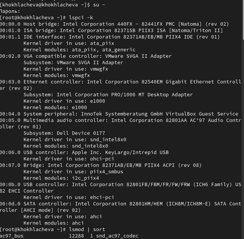

Просмотр

## Выполнение лабораторной работы

Загруженные модули ядра (рис. [-@fig:002]).

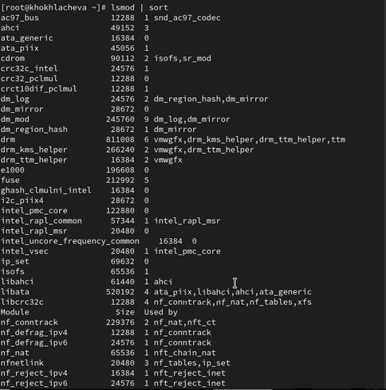

Модули

## Выполнение лабораторной работы

Смотрим загружен ли модуль ext4 и смотрим список загруженных модулей(рис. [-@fig:003]).

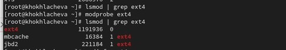

Просмотр

## Выполнение лабораторной работы

Выделенная информация поясняется тем, что модуль не принимает настроек при вызове; его поведение фиксировано или определяется внешними средствами.(рис. [-@fig:004]).

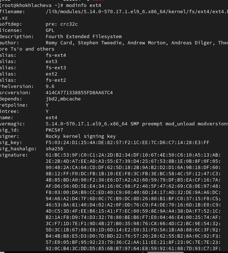

Информация

## Выполнение лабораторной работы

Пробуем выгрузить модуль ядра ext4 и также пробуем выгрузить модуль ядра xfs(рис. [-@fig:005]).

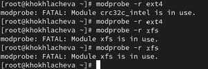

Выгрузка

## Выполнение лабораторной работы

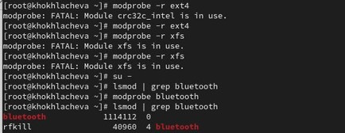

Модуль ядра

## Выполнение лабораторной работы

Это информация о модуле ядра Bluetooth версии 2.22 для Linux 5.14.0.

Модуль подписан, зависит от rfkill и, в отличие от предыдущего примера, имеет настраиваемые параметры для управления функциями Bluetooth (рис. [-@fig:007]).

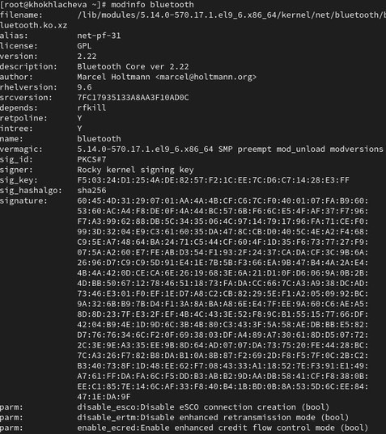

Модуль

## Выполнение лабораторной работы

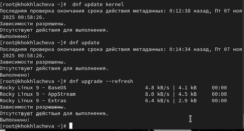

Обновление ядра

## Выполнение лабораторной работы

Просмотр версии ядра используемой в операционной системе(рис. [-@fig:009]).

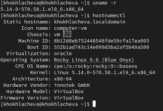

Просмотр

# Выводы

Мы получили навыки работы с утилитами управления модулями ядра операционной системы.